# Data preprocessing - Analysis

Sai Laasya Gorantla

2025-02-13

```r
### Installing libraries
if(!require('pacman'))
  install.packages('pacman')
```

```r
## Loading libraries
pacman :: p_load(
  RColorBrewer,
  plotly,
  janitor,
  tidytext,
  patchwork,
  colorspace,
  dplyr,
  dbscan,
  lubridate,
  readr,
  GGally,
  reshape2,
  tidyr,
  FNN)
```

# Carbondioxide Calibarations

Using the scada data from the scada mountain tower.

```r
scada <- read.csv('SCADA__MTNTWRCO2.csv', skip = 2)


## Reading the first 5 rows
head(scada)
```

```
##      ID            TIMESTAMP TRENDFLAGS STATUS    VALUE TRENDFLAGS_TAG
## 1 63893  2019/08/25 00:00:00          0      0 514.7742            { }
## 2 63894  2019/08/25 00:15:00          0      0 515.1938            { }
## 3 63895  2019/08/25 00:30:00          0      0 517.5016            { }
## 4 63896  2019/08/25 00:45:00          0      0 517.7954            { }
## 5 63897  2019/08/25 01:00:00          0      0 517.4597            { }
## 6 63898  2019/08/25 01:15:00          0      0 521.1104            { }
##   STATUS_TAG
## 1       {ok}
## 2       {ok}
## 3       {ok}
## 4       {ok}
## 5       {ok}
## 6       {ok}
```

```r
# Check for missing values in each column
colSums(is.na(scada))
```

```
##             ID      TIMESTAMP     TRENDFLAGS         STATUS          VALUE
##              0              0             14             14             14
## TRENDFLAGS_TAG     STATUS_TAG
##              0              0
```

```r
##Missing values
sum(is.na(scada))
```

```
## [1] 42
```

Counting the number as the readings takes place for every 15 min by sensor which means 96 per day.

```r
# Convert TIMESTAMP to a datetime format
scada <- scada %>% mutate(TIMESTAMP = as.POSIXct(TIMESTAMP, format = "%Y/%m/%d %H:%M:%S"))

# Filter for the year 2020
scada1 <- scada %>% filter(year(TIMESTAMP) == 2020)



##  Counting the number as the readings takes place for every 15 min
readings_per_day <- scada1 |> group_by(Date = date(TIMESTAMP)) %>% summarize(Readings = n())

##Missing date readings
missing_day <- readings_per_day |> filter(Readings != 96)

cat("Missing dates")
```

```
## Missing dates
```

```r
print(missing_day)
```

```
## # A tibble: 1 × 2
##   Date       Readings
##   <date>        <int>
## 1 2020-02-25       95
```

For every 15 min the sesnors takes the value for Carbondioxide that is released so which mean for every hour it will have 4 values for the entire day it will have 96 values.

The readings_per_day will count the number of readings per day

On the day of 2020-02-25 there are only 95 which means they lost a value. I can see the that at the timestamp 09:30 it wasn’t recorded. The trendflag at 09:45 seems to be 1 and the trendflag has the value{start}, dont what was starting at that moment.

If I have to fill the missing row, I am taking the mean of value from scada1 which considers the data for the year 2020 year only.

```r
# Check the data type of the column
class(scada1$VALUE)
```

```
## [1] "numeric"
```

```r
# Calculate the mean value for the year 2020
mean_value <- mean(scada1$VALUE)
print(mean_value)
```

```
## [1] 428.1858
```

The mean value for the VALUE column is 428.1858.

```r
# Group by day and calculate the mean value per day
mean_value_per_day <- scada1 |>
  group_by(Date = date(TIMESTAMP)) |>
  summarize(Mean = mean(VALUE))

# View the result
print(mean_value_per_day)
```

```
## # A tibble: 67 × 2
##    Date        Mean
##    <date>     <dbl>
##  1 2020-01-01  424.
##  2 2020-01-02  427.
##  3 2020-01-03  427.
##  4 2020-01-04  426.
##  5 2020-01-05  420.
##  6 2020-01-06  431.
##  7 2020-01-07  417.
##  8 2020-01-08  413.
##  9 2020-01-09  430.
## 10 2020-01-10  421.
## # ℹ 57 more rows
```

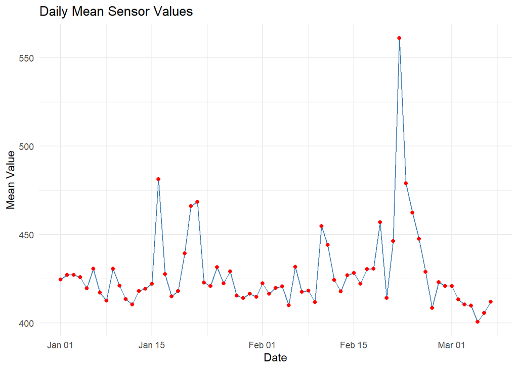

```r
# Plot daily mean values
ggplot(mean_value_per_day, aes(x = Date, y = Mean)) +
  geom_line(color = "steelblue") +
  geom_point(color = "red") +
  labs(title = "Daily Mean Sensor Values",
       x = "Date",
       y = "Mean Value") +
  theme_minimal()
```

```r
##Adding the new column mean_value_per_day to the readings per day column
# Join the mean values with the existing readings_per_day
readings_per_day <- readings_per_day |>
  left_join(mean_value_per_day, by = "Date")
```

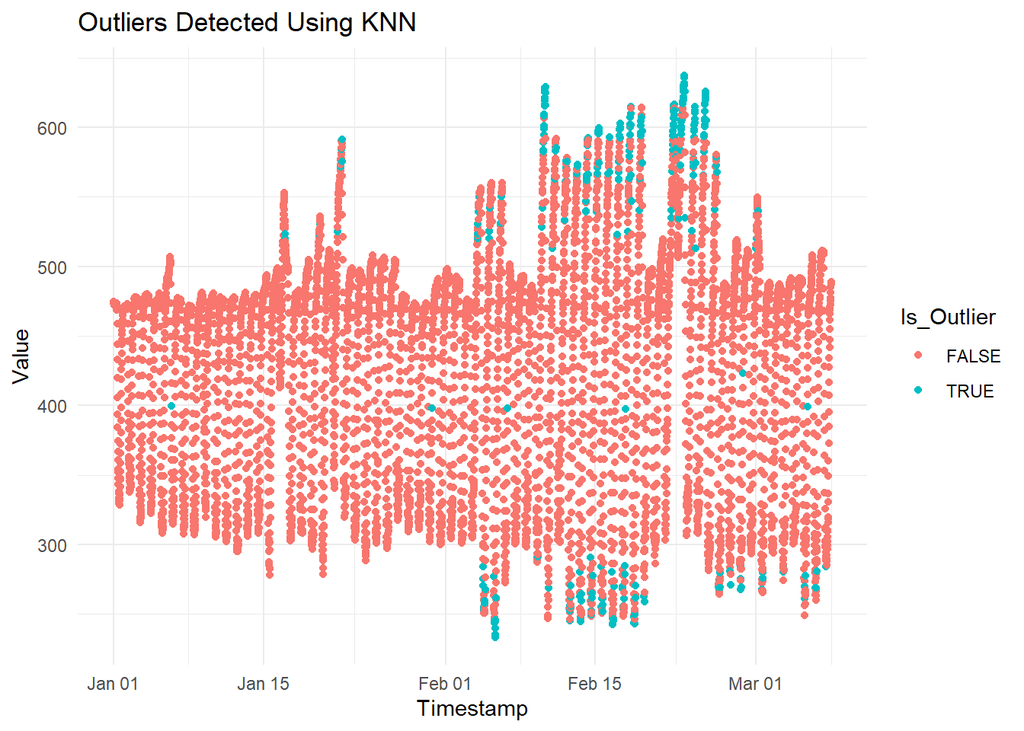

```r
# Extract the VALUE column for outlier detection
data_knn <- as.matrix(scada1$VALUE)

# Detecting outliers using KNN (k = 6)
knn_distances <- kNNdist(data_knn, k = 6)

# Use the 95th percentile as the threshold
outlier_threshold <- quantile(knn_distances, 0.95)
outliers <- knn_distances > outlier_threshold

# outlier information to the original data
scada1$Is_Outlier <- outliers

# Visualize the outliers
ggplot(scada1, aes(x = TIMESTAMP, y = VALUE, color = Is_Outlier)) +
  geom_point() +
  labs(title = "Outliers Detected Using KNN",
       x = "Timestamp",
       y = "Value") +
  theme_minimal()
```

#Outliers Calculating the outliers using KNN method and considering the value and using the threshold as 95 percentile

# Relative Humidity for the North East Tower.

```r
## Reading the humidity data file by skipping the two rows and put the header as False for not considering the name of the column
humidity <- read.csv("NE_Tower_Relative humidity.csv", skip = 4, header = FALSE)


# Taking off the null column the V7 by selecting 6 columns only
humidity <- humidity[, 1:6]



# Reassigning the column names as needed
colnames(humidity) <- c("DateTime", "TRF_NETower_100_HMP45", "TRF_NETower_300_HMP45","TRF_NETower_700_HMP45","TRF_NETower_1300_HMP45","TRF_NETower_2000_HMP45")
```

##Checking for the top 5 rows and also null values in the entire table and also for each column.

```r
## Reading the first 5 rows
head(humidity)
```

```
##           DateTime TRF_NETower_100_HMP45 TRF_NETower_300_HMP45
## 1 2019/08/25 00:00                  91.6                  97.9
## 2 2019/08/25 00:15                  91.6                  97.9
## 3 2019/08/25 00:30                  91.6                  97.9
## 4 2019/08/25 00:45                  91.6                  98.0
## 5 2019/08/25 01:00                  91.6                  98.0
## 6 2019/08/25 01:15                  91.5                  98.0
##   TRF_NETower_700_HMP45 TRF_NETower_1300_HMP45 TRF_NETower_2000_HMP45
## 1                  94.4                   95.6                   89.3
## 2                  94.5                   95.7                   89.2
## 3                  94.5                   95.7                   89.2
## 4                  94.5                   95.6                   89.1
## 5                  94.6                   95.6                   89.1
## 6                  94.6                   95.6                   89.1
```

```r
# Check for missing values in each column
colSums(is.na(humidity))
```

```
##               DateTime  TRF_NETower_100_HMP45  TRF_NETower_300_HMP45
##                      0                      0                      0
##  TRF_NETower_700_HMP45 TRF_NETower_1300_HMP45 TRF_NETower_2000_HMP45
##                      0                      0                      0
```

```r
##Missing values
sum(is.na(humidity))
```

```
## [1] 0
```

## The above code says that the file doesn’t have any null values in the North East Tower - the relative humidity. To make sure on then null values in the entire table and also in each of the column it’s zero.

```r
## Filtering out the '2020' data from humidity dataframe
humidity1 <- humidity |> filter(year(DateTime) == 2020)


##  Counting the number as the readings takes place for every 15 min
readings_per_day_humid <- humidity1 |> group_by(Date = date(DateTime)) %>% summarize(Readings = n())

##Missing date readings
missing_day_humid <- readings_per_day_humid |> filter(Readings != 96)

cat("Missing dates")
```

```
## Missing dates
```

```r
print(missing_day_humid)
```

```
## # A tibble: 0 × 2
## # ℹ 2 variables: Date <date>, Readings <int>
```

##This clarifies that there is no missing data in the Readings column which means they have recorded every single value through the sensors. So there is no need to perform any mean value to it.

# Performing calibration for the North East Sensors that is adding new columns

```r
#Generarting new columns for the humidity dataframe
humidity1 <- humidity1 %>%
  mutate(
    RH_NE_100_Corr  = TRF_NETower_100_HMP45  * 1.038 + 1.0,
    RH_NE_300_Corr  = TRF_NETower_300_HMP45  * 0.986 - 2.1,
    RH_NE_700_Corr  = TRF_NETower_700_HMP45  * 1.055 - 6.8,
     RH_NE_1300_Corr = TRF_NETower_1300_HMP45 * 0.9213 + 5.6,
    RH_NE_2000_Corr = TRF_NETower_2000_HMP45 * 0.9889 + 3.0,
   )

# View the updated dataframe
head(humidity1)
```

```
##           DateTime TRF_NETower_100_HMP45 TRF_NETower_300_HMP45
## 1 2020/01/01 00:00                 60.20                 62.09
## 2 2020/01/01 00:15                 60.20                 62.01
## 3 2020/01/01 00:30                 60.09                 61.85
## 4 2020/01/01 00:45                 59.83                 61.47
## 5 2020/01/01 01:00                 59.65                 61.37
## 6 2020/01/01 01:15                 59.33                 61.30
##   TRF_NETower_700_HMP45 TRF_NETower_1300_HMP45 TRF_NETower_2000_HMP45
## 1                 51.78                  51.32                  47.78
## 2                 51.33                  51.20                  47.72
## 3                 51.48                  51.09                  47.52
## 4                 51.32                  50.78                  47.38
## 5                 50.69                  50.70                  47.12
## 6                 50.90                  50.45                  46.99
##   RH_NE_100_Corr RH_NE_300_Corr RH_NE_700_Corr RH_NE_1300_Corr RH_NE_2000_Corr
## 1       63.48760       59.12074       47.82790        52.88112        50.24964
## 2       63.48760       59.04186       47.35315        52.77056        50.19031
## 3       63.37342       58.88410       47.51140        52.66922        49.99253
## 4       63.10354       58.50942       47.34260        52.38361        49.85408
## 5       62.91670       58.41082       46.67795        52.30991        49.59697
## 6       62.58454       58.34180       46.89950        52.07959        49.46841
```

## Performed the calculation as byu taking the formula and it’s the value for each column that is each sensor at particular heights.

```r
# Select columns starting with "RH"
rh_columns <- grep("RH", names(humidity1), value = TRUE)

# Subset the data using the selected column names
rh_data <- humidity1[, rh_columns]

# Calculate the mean of those columns
humid_mean <- colMeans(rh_data)

# Print the result
cat("Mean of the columns in the realtive humidity columns of the dataframe")
```

```
## Mean of the columns in the realtive humidity columns of the dataframe
```

```r
print(humid_mean)
```

```
##  RH_NE_100_Corr  RH_NE_300_Corr  RH_NE_700_Corr RH_NE_1300_Corr RH_NE_2000_Corr
##        78.50448        73.57304        68.11770        70.69086        68.35277
```

#Outliers for the North East Tower of Relative Humidity

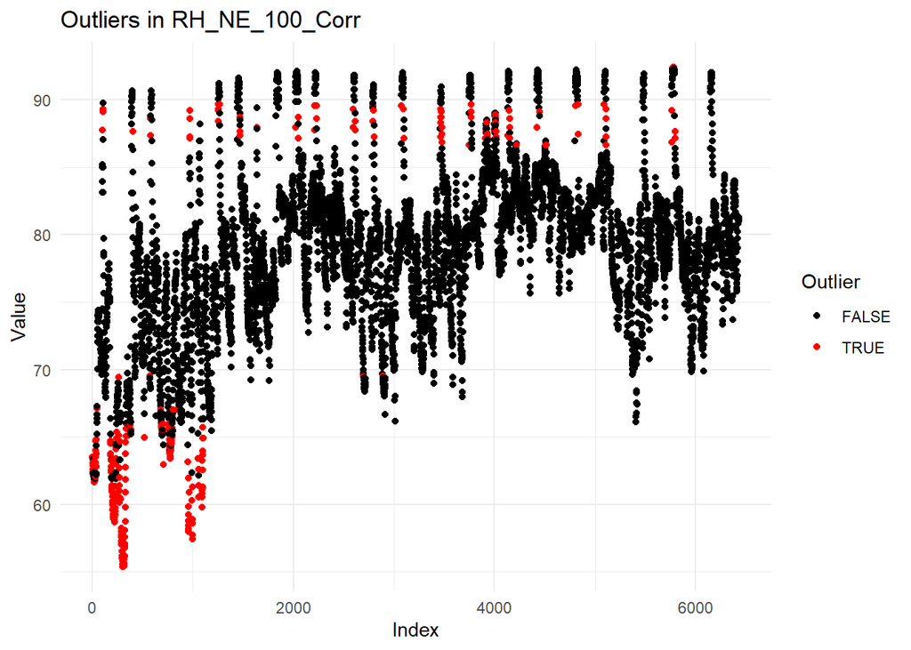

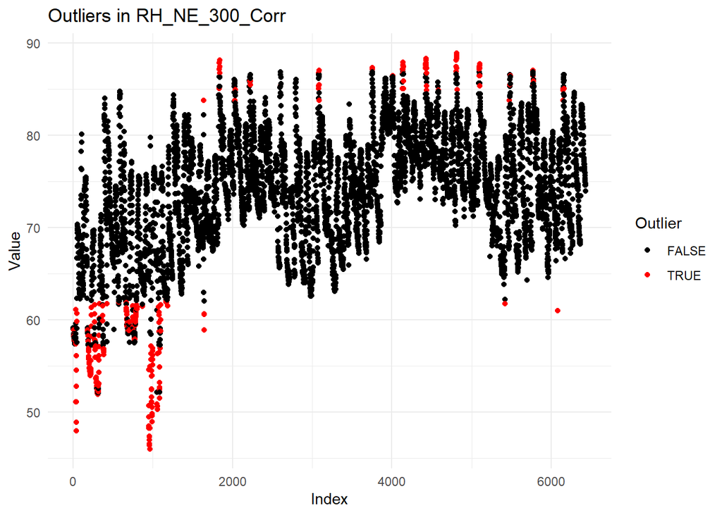

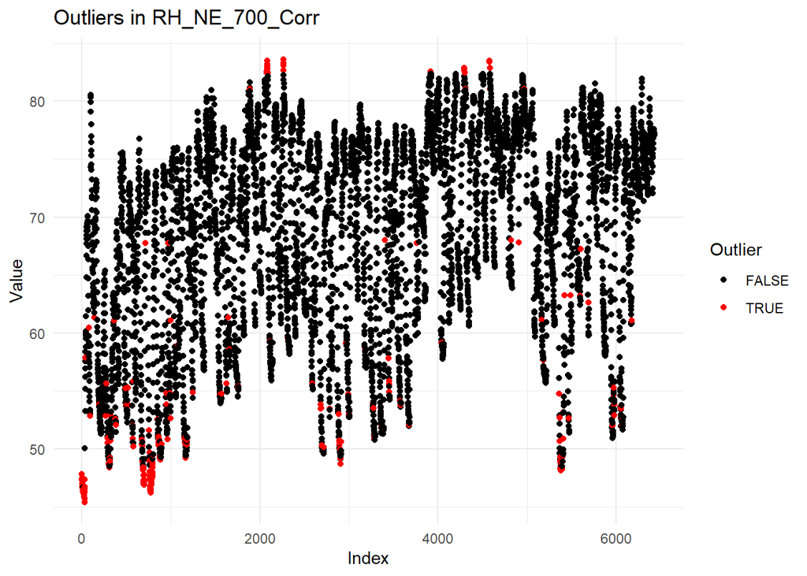

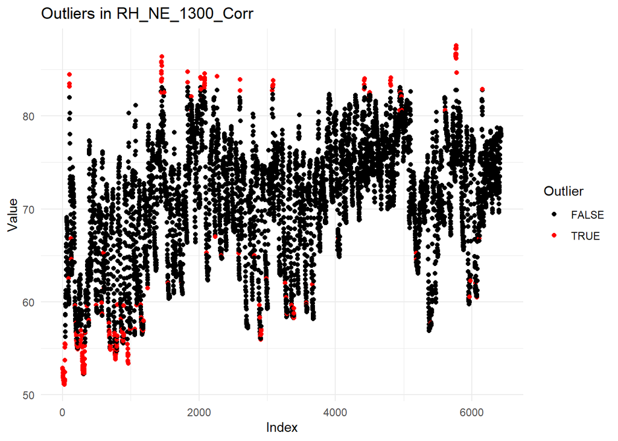

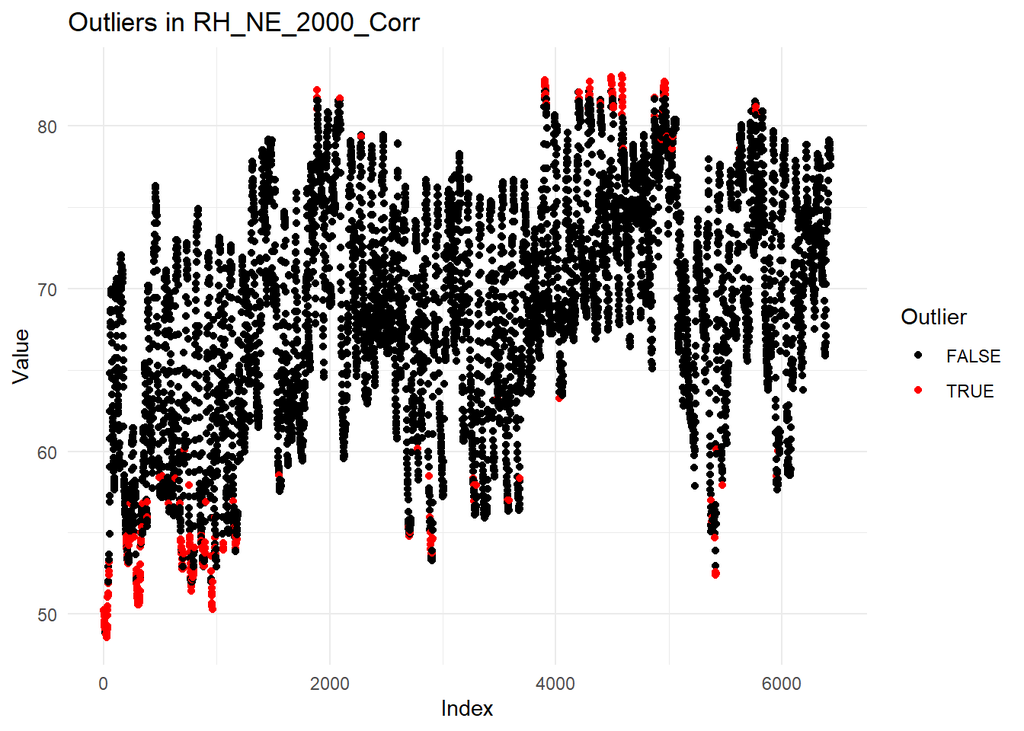

```r
# Select columns starting with "RH"
rh_columns <- grep("^RH", names(humidity1), value = TRUE)

# Considering values of those columns
humidity_rh <- humidity1[, rh_columns]

# Function to detect outliers using KNN
detect_outliers <- function(data) {

  # Compute KNN distances
  knn_dist <- knn.dist(as.matrix(data), k = 6)

  # Calculate the 95th percentile of distances for each point
  quantile_distances <- apply(knn_dist, 1, function(x) quantile(x, 0.95))

  # Identify outliers as points where the distance exceeds the 95th percentile
  outliers <- quantile_distances > quantile(quantile_distances, 0.95)

  return(outliers)
}

# Initialize a list to store outlier results
outlier_results <- list()

# Detect outliers for each column
for (col in rh_columns) {
  column_data <- humidity_rh[[col]]
  outliers <- detect_outliers(column_data)
  outlier_results[[col]] <- outliers
}

# Visualize outliers for each column
for (col in rh_columns) {
  # Create a data frame for plotting
  plot_data <- data.frame(
    Index = 1:nrow(humidity_rh),
    Value = humidity_rh[[col]],
    Outlier = outlier_results[[col]]
  )

  # Plot the data with outliers highlighted
  p <- ggplot(plot_data, aes(x = Index, y = Value, color = Outlier)) +
    geom_point() +
    scale_color_manual(values = c("black", "red")) +
    labs(title = paste("Outliers in", col),
         x = "Index",
         y = "Value") +
    theme_minimal()

  print(p)
}
```

# North East Temperature Calibrations

```r
##Importing the temperature dataset
temperature <- read.csv('NE_TowerTemperature.csv', skip = 4, header = FALSE)

# Taking off the null column the V7 by selecting 6 columns only
temperature <- temperature[, 1:6]


# Reassigning the column names as needed
colnames(temperature) <- c("DateTime", "TRF_NETower_100_HMP45", "TRF_NETower_300_HMP45","TRF_NETower_700_HMP45","TRF_NETower_1300_HMP45","TRF_NETower_2000_HMP45")
```

#Reading the top 5 and missing values in NE - Temperature

```r
## Reading the first 5 rows
head(temperature)
```

```
##           DateTime TRF_NETower_100_HMP45 TRF_NETower_300_HMP45
## 1 2019/08/25 00:00                 21.92                 21.33
## 2 2019/08/25 00:15                 21.88                 21.27
## 3 2019/08/25 00:30                 21.81                 21.19
## 4 2019/08/25 00:45                 21.74                 21.11
## 5 2019/08/25 01:00                 21.71                 21.00
## 6 2019/08/25 01:15                 21.67                 20.93
##   TRF_NETower_700_HMP45 TRF_NETower_1300_HMP45 TRF_NETower_2000_HMP45
## 1                 23.39                  22.89                  24.24
## 2                 23.35                  22.86                  24.15
## 3                 23.27                  22.81                  24.10
## 4                 23.21                  22.75                  24.02
## 5                 23.10                  22.67                  23.95
## 6                 23.00                  22.60                  23.85
```

```r
# Check for missing values in each column
colSums(is.na(temperature))
```

```
##               DateTime  TRF_NETower_100_HMP45  TRF_NETower_300_HMP45
##                      0                      0                      0
##  TRF_NETower_700_HMP45 TRF_NETower_1300_HMP45 TRF_NETower_2000_HMP45
##                      0                      0                      0
```

```r
##Missing values
sum(is.na(temperature))
```

```
## [1] 0
```

## The above code says that the file doesn’t have any null values in the North East Tower - the temperature. Making sure twice on null values for the entire table and also in each of the column.

```r
## Filtering out the '2020' data from temperature dataframe
temperature1 <- temperature |> filter(year(DateTime) == 2020)


##  Counting the number as the readings takes place for every 15 min
readings_per_day_temp<- temperature1 |> group_by(Date = date(DateTime)) %>% summarize(Readings = n())

##Missing date readingsof the temperature
missing_day_temp <- readings_per_day_temp |> filter(Readings != 96)

cat("Missing dates on NE Temperature")
```

```
## Missing dates on NE Temperature
```

```r
print(missing_day_temp)
```

```
## # A tibble: 0 × 2
## # ℹ 2 variables: Date <date>, Readings <int>
```

##This clarifies that there is no missing data in the Readings column which means they have recorded every single value through the sensors. So there is no need to perform any mean value to it.

```r
#Generating new columns for the temperature dataframe

temperature1 <-temperature1 %>%
  mutate(
    T_NE_100_Corr  = TRF_NETower_100_HMP45 * 1.032 - 0.58,
    T_NE_300_Corr  = TRF_NETower_300_HMP45 * 0.9883 + 0.6049,
    T_NE_700_Corr  = TRF_NETower_700_HMP45 * 1.045 - 0.88,
    T_NE_1300_Corr = TRF_NETower_1300_HMP45 * 1.007  - 0.08,
    T_NE_2000_Corr = TRF_NETower_2000_HMP45 * 0.9988 -0.39
   )

# View the updated dataframe
head(temperature1)
```

```
##           DateTime TRF_NETower_100_HMP45 TRF_NETower_300_HMP45
## 1 2020/01/01 00:00                 21.83                 23.36
## 2 2020/01/01 00:15                 21.82                 23.37
## 3 2020/01/01 00:30                 21.84                 23.42
## 4 2020/01/01 00:45                 21.87                 23.47
## 5 2020/01/01 01:00                 21.84                 23.43
## 6 2020/01/01 01:15                 21.82                 23.34
##   TRF_NETower_700_HMP45 TRF_NETower_1300_HMP45 TRF_NETower_2000_HMP45
## 1                 25.91                  25.30                  26.47
## 2                 26.03                  25.33                  26.47
## 3                 25.97                  25.36                  26.54
## 4                 25.98                  25.41                  26.52
## 5                 26.09                  25.35                  26.53
## 6                 25.94                  25.33                  26.47
##   T_NE_100_Corr T_NE_300_Corr T_NE_700_Corr T_NE_1300_Corr T_NE_2000_Corr
## 1      21.94856      23.69159      26.19595       25.39710       26.04824
## 2      21.93824      23.70147      26.32135       25.42731       26.04824
## 3      21.95888      23.75089      26.25865       25.45752       26.11815
## 4      21.98984      23.80030      26.26910       25.50787       26.09818
## 5      21.95888      23.76077      26.38405       25.44745       26.10816
## 6      21.93824      23.67182      26.22730       25.42731       26.04824
```

##Performed the calculation as byu taking the formula and it’s the value for each column that is each sensor at particular heights of the temperature dataframe.

#Average by each height

```r
# Select columns starting with "T_NE"
t_columns <- grep("T_NE", names(temperature1), value = TRUE)

# Subset the data using the selected column names
t_data <- temperature1[, t_columns]

# Calculate the mean of those columns
temp_mean <- colMeans(t_data)

# Print the result
cat("Mean of the columns in the temperature dataframe")
```

```
## Mean of the columns in the temperature dataframe
```

```r
print(temp_mean)
```

```
##  T_NE_100_Corr  T_NE_300_Corr  T_NE_700_Corr T_NE_1300_Corr T_NE_2000_Corr
##       22.63276       24.11882       25.40890       25.26319       25.95481
```

#Finally finding out the outliers of the NE-Temperature

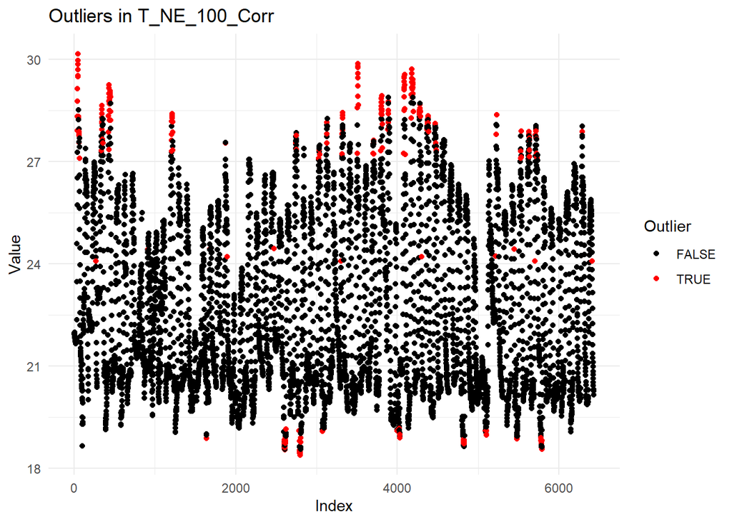

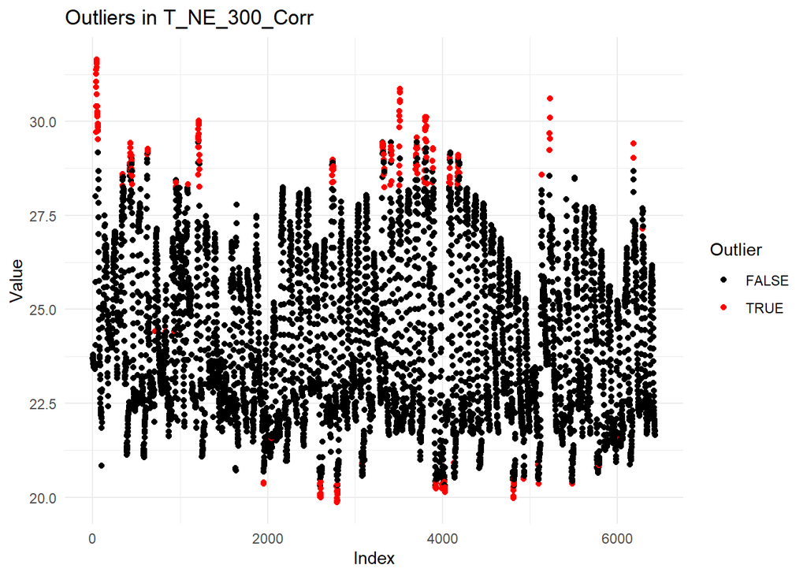

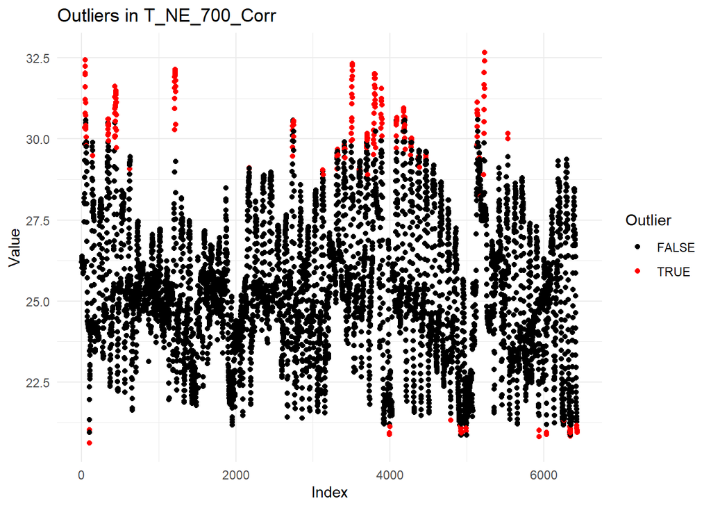

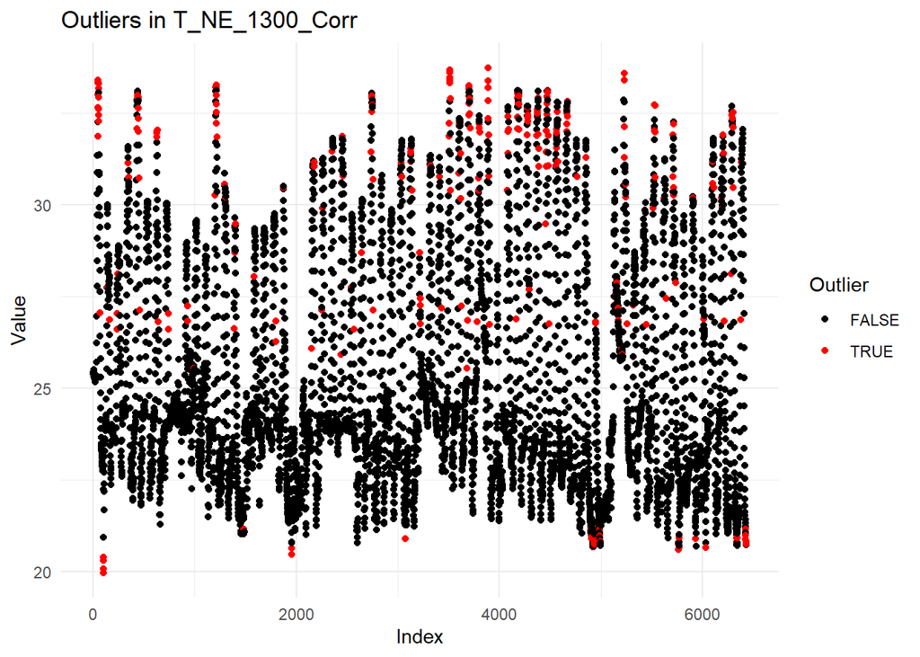

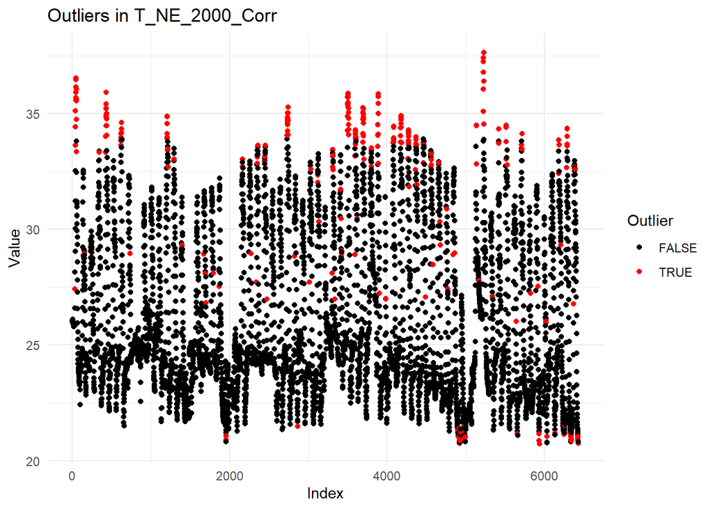

```r
# Select the corrected columns starting with "T_NE"
temp_columns <- grep("^T_NE", names(temperature1), value = TRUE)

# Considering values of those columns
temp_df <- temperature1[, temp_columns]

# Function to detect outliers using KNN
detect_outlier_temp <- function(data) {

  # Compute KNN distances
  knn_dist_temp <- knn.dist(as.matrix(data), k = 6)

  # Calculate the 95th percentile of distances for each point
  quantile_dist_temp <- apply(knn_dist_temp, 1, function(x) quantile(x, 0.95))

  # Identify outliers as points where the distance exceeds the 95th percentile
  outlier_temp <- quantile_dist_temp > quantile(quantile_dist_temp, 0.95)

  return(outlier_temp)
}

# Initialize a list to store outlier results
outlier_results <- list()

# Detect outliers for each column
for (col in temp_columns) {
  column_data <- temp_df[[col]]
  outliers <- detect_outlier_temp(column_data)
  outlier_results[[col]] <- outliers
}

# Visualize outliers for each column
for (col in temp_columns) {  # Corrected variable name from t_columns to temp_columns
  # Create a data frame for plotting
  plot_data <- data.frame(
    Index = 1:nrow(temp_df),  # Corrected variable name from temperature_t to temp_df
    Value = temp_df[[col]],   # Corrected variable name from temperature_t to temp_df
    Outlier = outlier_results[[col]]
  )

  # Plot the data with outliers highlighted
  p <- ggplot(plot_data, aes(x = Index, y = Value, color = Outlier)) +
    geom_point() +
    scale_color_manual(values = c("black", "red")) +
    labs(title = paste("Outliers in", col),
         x = "Index",
         y = "Value") +
    theme_minimal()

  print(p)
}
```

#Each day value according to the zone wise

### The whole system of the set up for the biosphere 2 is divided into three zones.

#Zone 1 - The south tower for 1m and 3m

```r
#Importing the other towers relative humidity and temperature for south, northwest and the mountain tower.

s_humid <- read.csv('C:/Users/ual-laptop/Desktop/NE/S_Tower_Relative humidity.csv', skip = 4, header = FALSE)

# Taking off the null column the V7 by selecting 6 columns only
s_humid <- s_humid[, 1:6]


# Reassigning the column names as needed
colnames(s_humid) <- c("DateTime", "TRF_STower_100_HMP45", "TRF_STower_300_HMP45","TRF_STower_700_HMP45","TRF_STower_1300_HMP45","TRF_SETower_2000_HMP45")

s_temp <- read.csv('C:/Users/ual-laptop/Desktop/NE/S_Tower_Relative humidity.csv', skip = 3, header = FALSE)

# Taking off the null column the V7 by selecting 6 columns only
s_temp <- s_humid[, 1:6]

# Reassigning the column names as needed
colnames(s_temp) <- c("DateTime", "TRF_STower_100_HMP45", "TRF_STower_300_HMP45","TRF_STower_700_HMP45","TRF_STower_1300_HMP45","TRF_SETower_2000_HMP45")
```

```r
nw_temp <- read.csv('C:/Users/ual-laptop/Desktop/NE/NW_Tower_Temperature.csv', skip = 4, header = FALSE)

# Taking off the null column the V6 by selecting 6 columns only
nw_temp <- nw_temp[, 1:5]

# Reassigning the column names as needed
colnames(nw_temp) <- c("DateTime", "TRF_NWTower_100_HMP45", "TRF_NWTower_300_HMP45","TRF_NWTower_700_HMP45","TRF_NWTower_1300_HMP45")


nw_humid <- read.csv('C:/Users/ual-laptop/Desktop/NE/NW_Tower_Temperature.csv', skip = 4, header = FALSE )

# Taking off the null column the V6 by selecting 6 columns only
nw_humid <- nw_humid[, 1:5]

# Reassigning the column names as needed
colnames(nw_humid) <- c("DateTime", "TRF_NWTower_100_HMP45", "TRF_NWTower_300_HMP45","TRF_NWTower_700_HMP45","TRF_NWTower_1300_HMP45")
```

```r
mtn_temp <- read.csv('C:/Users/ual-laptop/Desktop/NE/Mtn_Tower_Temperature.csv', skip = 4, header = FALSE)

# Taking off the null column the V6 by selecting 6 columns only
mtn_temp <- mtn_temp[, 1:5]

# Reassigning the column names as needed
colnames(mtn_temp) <- c("DateTime", "TRF_MTNTower_100_HMP45", "TRF_MTNTower_300_HMP45","TRF_MTNTower_700_HMP45","TRF_MTNTower_1300_HMP45")


mtn_humid <- read.csv('C:/Users/ual-laptop/Desktop/NE/Mtn_Tower_Temperature.csv', skip = 4, header = FALSE )

# Taking off the null column the V6 by selecting 6 columns only
mtn_humid <- mtn_humid[, 1:5]

# Reassigning the column names as needed
colnames(mtn_humid) <- c("DateTime", "TRF_MTNTower_100_HMP45", "TRF_MTNTower_300_HMP45","TRF_MTNTower_700_HMP45","TRF_MTNTower_1300_HMP45")
```

#Now filtering out and looking for null values in each tower file for the relative humidity and the temperature

#Null values for all towers relative humidity and humidity except NE

```r
# Function to check for NA values in each column
check_na_counts <- function(df, name) {
  na_counts <- colSums(is.na(df))
  cat(paste("NA counts for", name, "\n"))
  print(na_counts)

  return(na_counts)
}

# Applying functions to all datasets
na_nw_humid <- check_na_counts(nw_humid, "NW Humidity")
```

```
## NA counts for NW Humidity
##               DateTime  TRF_NWTower_100_HMP45  TRF_NWTower_300_HMP45
##                      0                      0                      0
##  TRF_NWTower_700_HMP45 TRF_NWTower_1300_HMP45
##                      0                      0
```

```r
na_nw_temp <- check_na_counts(nw_temp, "NW Temperature")
```

```
## NA counts for NW Temperature
##               DateTime  TRF_NWTower_100_HMP45  TRF_NWTower_300_HMP45
##                      0                      0                      0
##  TRF_NWTower_700_HMP45 TRF_NWTower_1300_HMP45
##                      0                      0
```

```r
na_mtn_humid <- check_na_counts(mtn_humid, "Mountain Humidity")
```

```
## NA counts for Mountain Humidity
##                DateTime  TRF_MTNTower_100_HMP45  TRF_MTNTower_300_HMP45
##                       0                       0                       0
##  TRF_MTNTower_700_HMP45 TRF_MTNTower_1300_HMP45
##                       0                       0
```

```r
na_mtn_temp <- check_na_counts(mtn_temp, "Mountain Temperature")
```

```
## NA counts for Mountain Temperature
##                DateTime  TRF_MTNTower_100_HMP45  TRF_MTNTower_300_HMP45
##                       0                       0                       0
##  TRF_MTNTower_700_HMP45 TRF_MTNTower_1300_HMP45
##                       0                       0
```

```r
na_s_humid <- check_na_counts(s_humid, "Southern Humidity")
```

```
## NA counts for Southern Humidity
##               DateTime   TRF_STower_100_HMP45   TRF_STower_300_HMP45
##                      0                      0                      0
##   TRF_STower_700_HMP45  TRF_STower_1300_HMP45 TRF_SETower_2000_HMP45
##                      0                      0                      0
```

```r
na_s_temp <- check_na_counts(s_temp, "Southern Temperature")
```

```
## NA counts for Southern Temperature
##               DateTime   TRF_STower_100_HMP45   TRF_STower_300_HMP45
##                      0                      0                      0
##   TRF_STower_700_HMP45  TRF_STower_1300_HMP45 TRF_SETower_2000_HMP45
##                      0                      0                      0
```

#Filtering out 2020 and checking out for 96 readings

```r
# Function to filter and find missing readings

process_data <- function(tower, name) {
  tower_2020 <- tower |> filter(year(DateTime) == 2020)
  readings_per_day <- tower_2020 |> group_by(Date = date(DateTime)) |> summarize(Readings = n())
  missing_days <- readings_per_day |> filter(Readings != 96)

  cat(paste("Missing dates on", name, "\n"))
  print(missing_days)

  return(tower_2020)
}

# Applying the function to all datasets
nw_humid_2020 <- process_data(nw_humid, "NW Humidity")
```

```
## Missing dates on NW Humidity
## # A tibble: 0 × 2
## # ℹ 2 variables: Date <date>, Readings <int>
```

```r
nw_temp_2020 <- process_data(nw_temp, "NW Temperature")
```

```
## Missing dates on NW Temperature
## # A tibble: 0 × 2
## # ℹ 2 variables: Date <date>, Readings <int>
```

```r
mtn_humid_2020 <- process_data(mtn_humid, "Mountain Humidity")
```

```
## Missing dates on Mountain Humidity
## # A tibble: 0 × 2
## # ℹ 2 variables: Date <date>, Readings <int>
```

```r
mtn_temp_2020 <- process_data(mtn_temp, "Mountain Temperature")
```

```
## Missing dates on Mountain Temperature
## # A tibble: 0 × 2
## # ℹ 2 variables: Date <date>, Readings <int>
```

```r
s_humid_2020 <- process_data(s_humid, "Southern Humidity")
```

```
## Missing dates on Southern Humidity
## # A tibble: 0 × 2
## # ℹ 2 variables: Date <date>, Readings <int>
```

```r
s_temp_2020 <- process_data(s_temp, "Southern Temperature")
```

```
## Missing dates on Southern Temperature
## # A tibble: 0 × 2
## # ℹ 2 variables: Date <date>, Readings <int>
```

#Calibration

###Performing calibrations for Mountain Tower with the sensor to each temperature and relative humidity.

```r
mtn_temp_2020 <- mtn_temp_2020 %>%
  mutate(
    T_MTN_100_Corr  = TRF_MTNTower_100_HMP45,
    T_MTN_300_Corr  = TRF_MTNTower_300_HMP45 * 0.9383 + 1.67,
    T_MTN_700_Corr  = TRF_MTNTower_700_HMP45 * 1.129 - 2.4,
    T_MTN_1300_Corr = TRF_MTNTower_1300_HMP45 * 1.004 - 0.02
  )

mtn_humid_2020 <- mtn_humid_2020 %>%
  mutate(
    RH_MTN_100_Corr  = TRF_MTNTower_100_HMP45,
    RH_MTN_300_Corr  = TRF_MTNTower_300_HMP45 * 0.8975 + 12.2,
    RH_MTN_700_Corr  = TRF_MTNTower_700_HMP45 * 0.863 + 16.2,
    RH_MTN_1300_Corr = TRF_MTNTower_1300_HMP45 * 1.008 + 1.1
  )
```

### #Performing calibrations for North West Tower with the sensor to each temperature and relative humidity.

```r
nw_temp_2020 <- nw_temp_2020 %>%
  mutate(
    T_NW_100_Corr  = TRF_NWTower_100_HMP45 * 0.9922 + 0.6,
    T_NW_300_Corr  = TRF_NWTower_300_HMP45 * 1.005 - 0.17,
    T_NW_700_Corr  = TRF_NWTower_700_HMP45 * 1.007 - 0.14,
    T_NW_1300_Corr = TRF_NWTower_1300_HMP45 * 0.9801 + 0.54
  )

nw_humid_2020 <- nw_humid_2020 %>%
  mutate(
    RH_NW_100_Corr  = TRF_NWTower_100_HMP45 * 0.9756 - 1.2,
    RH_NW_300_Corr  = TRF_NWTower_300_HMP45 * 0.9882 - 1.6,
    RH_NW_700_Corr  = TRF_NWTower_700_HMP45 * 0.9895 + 1.1,
    RH_NW_1300_Corr = TRF_NWTower_1300_HMP45 * 1.012 + 1.334
  )
```

### #Performing calibrations for South Tower with the sensor to each temperature and relative humidity.

```r
s_temp_2020 <- s_temp_2020 %>%
  mutate(
    T_S_100_Corr  = TRF_STower_100_HMP45 * 1.041 + 0.08,
    T_S_300_Corr  = TRF_STower_300_HMP45 * 1.026 - 0.04,
    T_S_700_Corr  = TRF_STower_700_HMP45 * 1.037 - 0.15,
    T_S_1300_Corr = TRF_STower_1300_HMP45 * 1.059 - 0.31,
    T_S_2000_Corr = TRF_SETower_2000_HMP45  # No calibration needed
  )


s_humid_2020 <- s_humid_2020 %>%
  mutate(
    RH_S_100_Corr  = TRF_STower_100_HMP45 * 0.996 + 0.1,
    RH_S_300_Corr  = TRF_STower_300_HMP45 * 1.04 - 2.4,
    RH_S_700_Corr  = TRF_STower_700_HMP45 * 1.053 + 1.1,
    RH_S_1300_Corr = TRF_STower_1300_HMP45 * 0.9499 + 7.4,
    RH_S_2000_Corr = TRF_SETower_2000_HMP45  # No calibration needed
  )
```

#Zone wise calibrations

```r
zone1_data <- s_temp_2020 %>%
  mutate(Date = as.Date(DateTime)) %>%
  group_by(Date) %>%
  summarize(
    Zone_1_Temp_Avg = mean(c(s_temp_2020$T_S_100_Corr, s_temp_2020$T_S_300_Corr, temperature1$T_NE_100_Corr, temperature1$T_NE_300_Corr), na.rm = TRUE),
    Zone_1_RH_Avg = mean(c(s_humid_2020$RH_S_100_Corr, s_humid_2020$RH_S_300_Corr, humidity1$RH_NE_100_Corr, humidity1$RH_NE_300_Corr), na.rm = TRUE)
  )

# View first few rows of Zone 1 data
print("Zone 1 Data:")
```

```
## [1] "Zone 1 Data:"
```

```r
print(head(zone1_data))
```

```
## # A tibble: 6 × 3
##   Date       Zone_1_Temp_Avg Zone_1_RH_Avg
##   <date>               <dbl>         <dbl>
## 1 2020-01-01            53.5          78.6
## 2 2020-01-02            53.5          78.6
## 3 2020-01-03            53.5          78.6
## 4 2020-01-04            53.5          78.6
## 5 2020-01-05            53.5          78.6
## 6 2020-01-06            53.5          78.6
```

```r
# Zone 2 calculation (Temperature and Humidity from NW (100-300), South (700-1300), Northeast (700-1300))

zone2_data <- nw_temp_2020 %>%
  mutate(Date = as.Date(DateTime)) %>%
  group_by(Date) %>%
  summarize(
    Zone_2_Temp_Avg = mean(c(
      nw_temp_2020$T_NW_100_Corr,
      nw_temp_2020$T_NW_300_Corr,
      s_temp_2020$T_S_700_Corr,
      s_temp_2020$T_S_1300_Corr,
      temperature1$T_NE_700_Corr,
      temperature1$T_NE_1300_Corr), na.rm = TRUE),

    Zone_2_RH_Avg = mean(c(
      nw_humid$RH_NW_100_Corr,
      nw_humid$RH_NW_300_Corr,
      s_humid_2020$RH_S_700_Corr,
      s_humid_2020$RH_S_1300_Corr,
      humidity1$RH_NE_700_Corr,
      humidity1$RH_NE_1300_Corr), na.rm = TRUE)
  )

# View first few rows of Zone 2 data
print("Zone 2 Data:")
```

```
## [1] "Zone 2 Data:"
```

```r
print(head(zone2_data))
```

```
## # A tibble: 6 × 3
##   Date       Zone_2_Temp_Avg Zone_2_RH_Avg
##   <date>               <dbl>         <dbl>
## 1 2020-01-01            41.0          71.8
## 2 2020-01-02            41.0          71.8
## 3 2020-01-03            41.0          71.8
## 4 2020-01-04            41.0          71.8
## 5 2020-01-05            41.0          71.8
## 6 2020-01-06            41.0          71.8
```

```r
# Zone 3 calculation (Temperature and Humidity from South (2000), NW (1300), Mtn (1300-2000), Northeast (2000))

zone3_data <- nw_temp_2020 %>%
  mutate(Date = as.Date(DateTime)) %>%
  group_by(Date) %>%
  summarize(
    Zone_3_Temp_Avg = mean(c(
      s_temp_2020$T_S_2000_Corr,
      nw_temp_2020$T_NW_1300_Corr,
      mtn_temp_2020$T_Mtn_1300_Corr,
      mtn_temp_2020$T_Mtn_2000_Corr,
      temperature1$T_NE_2000_Corr), na.rm = TRUE),

    Zone_3_RH_Avg = mean(c(
      s_humid_2020$RH_S_2000_Corr,
      nw_humid_2020$RH_NW_1300_Corr,
      mtn_humid_2020$RH_Mtn_1300_Corr,
      mtn_humid_2020$RH_Mtn_2000_Corr,
      humidity1$RH_NE_2000_Corr), na.rm = TRUE)
  )

# View first few rows of Zone 3 data
print("Zone 3 Data:")
```

```
## [1] "Zone 3 Data:"
```

```r
print(head(zone3_data))
```

```
## # A tibble: 6 × 3
##   Date       Zone_3_Temp_Avg Zone_3_RH_Avg
##   <date>               <dbl>         <dbl>
## 1 2020-01-01            41.9          56.6
## 2 2020-01-02            41.9          56.6
## 3 2020-01-03            41.9          56.6
## 4 2020-01-04            41.9          56.6
## 5 2020-01-05            41.9          56.6
## 6 2020-01-06            41.9          56.6
```